# Statistical analysis (main dependent variable)

Brent J. Raiteri (on data from Paolo Tecchio’s hybrid 3D fascicle tractography approach)  
2026-02-27

## Fascicle length from DTI

Fixed effects were fitted using a linear mixed-effects model. Model-based standard errors and p-values are presented. Sandwich variance estimation-based standard errors and p-values were also produced; these do not assume normality of the data.

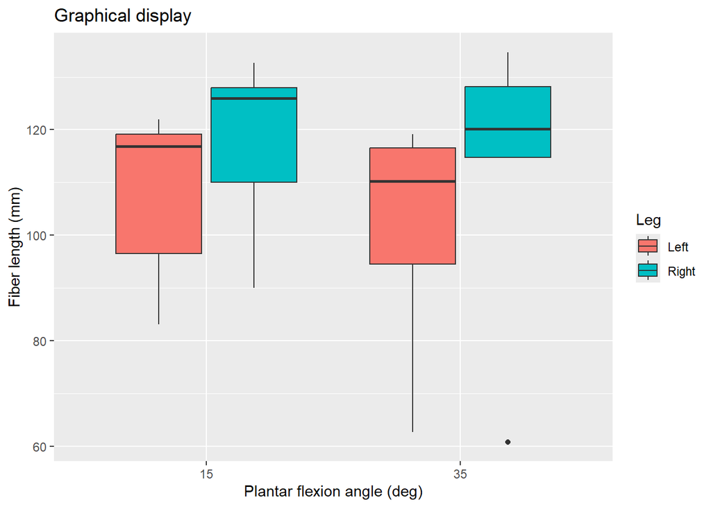

## Fixed-effects model with interaction

This fixed-effects model fits the factors plantar flexion angle and leg with random intercepts and fixed slopes and a fixed angle x leg interaction.  
We first compared fitting the model by REML vs. ML, and REML resulted in a better fit:

```
## $statistics
##                      aic     bic bayes.factor
## interaction_REML 143.767 149.741     27332.26
## interaction_ML   164.198 170.173         0.00
##
## $predicted_differences
##   0%  25%  50%  75% 100%
##    0    0    0    0    0
```

## Model summary

```
## Linear mixed model fit by REML. t-tests use Satterthwaite's method [
## lmerModLmerTest]
## Formula: lendti ~ angle * leg + (1 | id)
##    Data: d
##
## REML criterion at convergence: 131.8
##
## Scaled residuals:
##     Min      1Q  Median      3Q     Max
## -2.1261 -0.4020 -0.1157  0.3976  1.5312
##
## Random effects:
##  Groups   Name        Variance Std.Dev.
##  id       (Intercept) 436.00   20.881
##  Residual              64.09    8.005
## Number of obs: 20, groups:  id, 5
##
## Fixed effects:
##             Estimate Std. Error      df t value Pr(>|t|)
## (Intercept)  107.480     10.001   4.878  10.747  0.00014 ***
## angle2        -6.880      5.063  12.000  -1.359  0.19919
## leg2           9.840      5.063  12.000   1.943  0.07578 .
## angle2:leg2    1.260      7.160  12.000   0.176  0.86325
## ---
## Signif. codes:  0 '***' 0.001 '**' 0.01 '*' 0.05 '.' 0.1 ' ' 1
##
## Correlation of Fixed Effects:
##             (Intr) angle2 leg2
## angle2      -0.253
## leg2        -0.253  0.500
## angle2:leg2  0.179 -0.707 -0.707
```

## Model- & sandwich-based standard errors and p-values

```
## Model- & sandwich-based standard errors and p-values
```

```
## Click on the arrow for sandwich-based p-values.
```

```
## # A tibble: 4 × 6
##   term        estimate `Model-based s.e.` `Model-based p-value` `Sandwich s.e.`
##   <chr>          <dbl>              <dbl>                 <dbl>           <dbl>
## 1 (Intercept)   107.                10.0           0.0000000380            7.57
## 2 angle2         -6.88               5.06          0.196                   3.58
## 3 leg2            9.84               5.06          0.0723                  1.10
## 4 angle2:leg2     1.26               7.16          0.863                   3.82
##   `Sandwich p-value`
##                <dbl>
## 1           0.000143
## 2           0.127
## 3           0.000877
## 4           0.758
```

## Estimated marginal means

Estimated marginal means (EMMs) for the fixed-effects model with a fixed angle x leg interaction are reported below, which explicitly use cluster-robust standard errors (accounting for non-independent data or heteroskedasticity). This approach was used to ensure that the confidence intervals and subsequent p-values for the EMMs are more accurate and reliable.

```
## leg = 1:
##  angle emmean    SE   df lower.CL upper.CL
##  1        107  7.57 4.88     87.9      127
##  2        101 10.40 4.88     73.7      128
##
## leg = 2:
##  angle emmean    SE   df lower.CL upper.CL
##  1        117  7.82 4.88     97.1      138
##  2        112 13.20 4.88     77.6      146
##
## Degrees-of-freedom method: satterthwaite
## Confidence level used: 0.95
```

```
##  angle emmean    SE   df lower.CL upper.CL
##  1        112  7.68 4.29     91.6      133
##  2        106 11.60 4.29     74.7      138
##
## Results are averaged over the levels of: leg
## Degrees-of-freedom method: satterthwaite
## Confidence level used: 0.95
```

```
##  contrast        estimate   SE df t.ratio p.value
##  angle2 - angle1    -6.25 5.09 12  -1.228  0.2431
##
## Results are averaged over the levels of: leg
## Degrees-of-freedom method: satterthwaite
```